# data-replication

Riley N Derby

2024-04-01

Data-replication assignment

Introduction: I will be replicating results from a paper entitled “Adolescent male chimpanzees (Pan troglodytes) form social bonds with their brothers and others during the transition to adulthood” by Sandel et al.

This paper explores social bonds during an understudied period of development. Although social bonds have been largely studied in adult chimpanzees, their development, and when they are formed is not well understood. The authors establish a precedent for bonds being formed between male chimpanzees of similar age, rank, and between maternal kin. However, adolescent males do not form hierarchies with one another, so do they still form bonds? And if so, who do they form bonds with?

In order to answer these questions, the authors observed a total of 18 chimpanzees from Ngogo over the course of a year. 10 were adolescents between ages 12-16, and 8 were young adults between ages 17-21. They collected behavioral data including association (within the same party), proximity, and grooming interactions. Age was calculated based on observed births. Kinship was calculated using 19-44 autosomal microsatellietes in addition to mitochondrial DNA as in previous studies of the population. This allowed for classification of the kin categories (maternal brothers, paternal brothers, father and sons, or unrelated). Unrelated individuals included all types of dyads including distant relatives such as uncle and nephew or cousins.

Visualization of Data:

Let’s start out by referencing all the packages we need for this assignment

```r
library(tidyverse)
library(MuMIn)
library(lme4)
```

```r
library(ggplot2)
library(reshape2)
library(dplyr)
library(magrittr)
library(htmltools)
```

Now let’s load in the data from the study and get an idea of how it looks

```r
data <- read_csv("C:/Users/rnder/OneDrive/Desktop/2020_redo/dyad_DATA_Jan2019.csv")
glimpse(data)
```

```
## Rows: 954
## Columns: 23
## $ Dyad           <chr> "Abrams_Dylan", "Barron_Dylan", "Benny_Dylan", "Booker_…
## $ FocalID        <chr> "Abrams", "Barron", "Benny", "Booker", "Buckner", "Djan…
## $ IndividualID   <chr> "Dylan", "Dylan", "Dylan", "Dylan", "Dylan", "Dylan", "…
## $ Father         <chr> "NoDad", "NoDad", "NoDad", "NoDad", "NoDad", "NoDad", "…
## $ Mat_Bro        <chr> "NoBro", "NoBro", "NoBro", "NoBro", "NoBro", "NoBro", "…
## $ Pat_Bro        <chr> "NoBro", "NoBro", "NoBro", "NoBro", "NoBro", "NoBro", "…
## $ Family         <chr> "Unrelated", "Unrelated", "Unrelated", "Unrelated", "Un…
## $ Focal_age      <dbl> 14.76, 13.51, 14.26, 12.39, 14.68, 17.68, 12.67, 18.68,…
## $ ID2_age        <dbl> 8.11, 8.11, 8.11, 8.11, 8.11, 8.11, 8.11, 8.11, 8.11, 8…
## $ Age_Diff       <dbl> -6.65, -5.40, -6.15, -4.28, -6.57, -9.57, -4.56, -10.57…
## $ Total_Scans    <dbl> 297, 283, 314, 305, 298, 309, 314, 313, 313, 248, 325, …
## $ Total_Hours    <dbl> 42.85, 41.91, 43.22, 43.99, 41.71, 44.26, 46.36, 45.11,…
## $ Total_Minutes  <dbl> 2571.0, 2514.6, 2593.2, 2639.4, 2502.6, 2655.6, 2781.6,…
## $ Total_Follows  <dbl> 45, 45, 45, 46, 45, 46, 48, 47, 46, 38, 50, 46, 38, 43,…
## $ tally_Within1  <dbl> 0, 0, 0, 0, 0, 0, 0, 0, 0, 0, 0, 0, 0, 1, 0, 0, 0, 0, 0…
## $ tally_One_Five <dbl> 5, 1, 0, 1, 0, 0, 0, 1, 1, 0, 1, 6, 0, 1, 0, 1, 0, 0, 0…
## $ Within_Five    <dbl> 5, 1, 0, 1, 0, 0, 0, 1, 1, 0, 1, 6, 0, 2, 0, 1, 0, 0, 0…
## $ Five_Twenty    <dbl> 0, 2, 0, 1, 0, 2, 2, 3, 2, 0, 3, 14, 0, 2, 2, 0, 0, 0, …
## $ AlloGr         <dbl> 0.00, 0.00, 0.00, 0.00, 0.00, 0.00, 0.00, 0.00, 0.00, 0…
## $ MutlGr         <dbl> 0, 0, 0, 0, 0, 0, 0, 0, 0, 0, 0, 0, 0, 0, 0, 0, 0, 0, 0…
## $ RecvGr         <dbl> 0.00, 0.00, 0.00, 0.00, 0.00, 0.00, 0.00, 0.00, 0.00, 0…
## $ Groom          <dbl> 0.00, 0.00, 0.00, 0.00, 0.00, 0.00, 0.00, 0.00, 0.00, 0…
## $ Association    <dbl> 13, 10, 2, 15, 2, 10, 9, 8, 14, 3, 12, 23, 5, 10, 8, 1,…
```

```r
#lets find how many unique individuals are in the study
nodes <- as.data.frame(unique(data$IndividualID)) #number of males in the study == 54 males
```

Lets also load in a demography file I have from Ngogo to do a quick visual cross check for some of these relationships

```r
demog <- read_csv("C:/Users/rnder/OneDrive/Desktop/2020_redo/demographyForNetworks_22.csv")
glimpse(demog)
```

```
## Rows: 227
## Columns: 12
## $ individualID <chr> "Porkpie", "Peterson", "Django", "Haden", "Abrams", "Lova…
## $ DOB          <chr> "1/1/94", "1/1/95", "1/1/97", "1/1/99", "12/1/99", "12/1/…
## $ Sex          <chr> "Male", "Male", "Male", "Male", "Male", "Male", "Male", "…
## $ mother       <chr> NA, "Aretha", "Betty", "Lita", "Callas", "Fitzgerald", "K…
## $ father       <chr> "Parker", "Garrison", "Dizzy", "Rude", "Ornette", "Hodge"…
## $ Maturity     <chr> "Independent", "Independent", "Independent", "Independent…
## $ ID_notes     <chr> NA, NA, NA, NA, NA, NA, NA, NA, NA, NA, NA, NA, NA, NA, N…
## $ neighborhood <chr> "central", "central", "central", "central", "central", "c…
## $ community    <chr> "central", "central", "central", "central", "central", "c…
## $ Focal        <dbl> 1, 1, 1, 1, 1, 1, 1, 1, 1, 1, 1, 1, 1, 1, 1, 0, 0, 0, 0, …
## $ ogFocal      <dbl> 1, 1, 1, 1, 1, 1, 1, 1, 1, 1, 0, 0, 0, 0, 0, 0, 0, 0, 0, …
## $ goneBy2018   <dbl> 0, 0, 0, 0, 0, 0, 0, 0, 0, 0, 0, 0, 0, 0, 0, 0, 1, 1, 1, …
```

```r
demog1 <- demog %>%
  filter(Sex == "Male")%>%#narrow down to males for a visual check of relationships
  arrange(mother)


demog2 <- right_join(demog1, nodes, by = c("individualID" = "unique(data$IndividualID)"))## Hawkins is in this file twice so lets eliminate row 2

#eliminate row 2 in demog2 file
demog2 <- demog2[-2, ]
```

Here is a list of known maternal brothers from visual check of demog2: Peterson-Carter; Django-Barktok-Basie; Abrams-Jarman; Benny-Jackson-Yoyo; Lovano-Dylan; Monk-Richmond-Hutcherson; Hare-Morton; Damien-Rollins; Wilson-Elton; Rashaan-Wayne; Mulligan-Mitchell; Booker-Evans; Barron-Orff-Garett

lets look at paternal brothers now

```r
demog2 <- demog2 %>%
  arrange(father)
```

Here is a list of known paternal brothers from visual check: Wilson-Wayne-Evans; Peterson-Benny-Yoyo; Hicks-Buckner-Erroll-Orff; Hawkins-Lovano-Booker-Barron; Bosko-Elton; Wes-Murray; Hutcherson-Porkpie; Damien-Rollins-Rashaan; Jackson-Monk-Haden-Miles

```r
##narrow down to fathers that appear in nodes data
demog3 <- inner_join(demog2, nodes, by = c("father" = "unique(data$IndividualID)"))

demog3 <- demog3%>%
  arrange(father)
```

Here is a list of Father-son pairs from visual check: Bartok-Evans, Wilson, Wayne; Brownface-Garett; Dizzy-Django; Dexter-Chopin;Garrison-Peterson, Benny, Yoyo; Hare-Hicks, Buckner,Erroll,Orff; Miles-Wes, Murray; Monk-Jarman; Morton-BillyBragg; Mulligan-Peewee; Mweya-Dexter; Ornette-Abrams

lets pull back up our dataset and do a quick visual check

```r
#pull at matbros to the top to cross-check with our list

#Peterson-Carter; Django-Barktok-Basie; Abrams-Jarman; Benny-Jackson-Yoyo; Lovano-Dylan; Monk-Richmond-Hutcherson; Hare-Morton; Damien-Rollins; Wilson-Elton; Rashaan-Wayne; Mulligan-Mitchell; Booker-Evans; Barron-Orff-Garett

data %>%
  arrange(Mat_Bro)
```

```
## # A tibble: 954 × 23
##    Dyad     FocalID IndividualID Father Mat_Bro Pat_Bro Family Focal_age ID2_age
##    <chr>    <chr>   <chr>        <chr>  <chr>   <chr>   <chr>      <dbl>   <dbl>
##  1 Lovano_… Lovano  Dylan        NoDad  MatBro  NoBro   MatBro      14.9    8.11
##  2 Wilson_… Wilson  Elton        NoDad  MatBro  NoBro   MatBro      14.8    8.11
##  3 Benny_Y… Benny   YoYo         NoDad  MatBro  Bro     MatBro      14.3    8.67
##  4 Abrams_… Abrams  Jarman       NoDad  MatBro  NoBro   MatBro      14.8    9.67
##  5 Barron_… Barron  Orff         NoDad  MatBro  NoBro   MatBro      13.5    9.67
##  6 Evans_B… Evans   Booker       NoDad  MatBro  NoBro   MatBro      18.7   12.4
##  7 Booker_… Booker  Evans        NoDad  MatBro  NoBro   MatBro      12.4   18.7
##  8 Benny_J… Benny   Jackson      NoDad  MatBro  NoBro   MatBro      14.3   23.7
##  9 Peterso… Peters… Carter       NoDad  MatBro  NoBro   MatBro      19.7   24.7
## 10 Barron_… Barron  Garett       NoDad  MatBro  NoBro   MatBro      13.5   25.7
## # ℹ 944 more rows
## # ℹ 14 more variables: Age_Diff <dbl>, Total_Scans <dbl>, Total_Hours <dbl>,
## #   Total_Minutes <dbl>, Total_Follows <dbl>, tally_Within1 <dbl>,
## #   tally_One_Five <dbl>, Within_Five <dbl>, Five_Twenty <dbl>, AlloGr <dbl>,
## #   MutlGr <dbl>, RecvGr <dbl>, Groom <dbl>, Association <dbl>
```

-Benny-Yoyo are full brothers but looks like authors chose to keep them as simply maternal brothers in family classification. -Not all MatBros interacted, but Mulligan-Mitchell did, but they are not included in Matbro category right now so we will fix that before analyses

```r
#pull all patbros to the top to cross-check with our list
#Wilson-Wayne-Evans; Peterson-Benny-Yoyo; Hicks-Buckner-Erroll-Orff; Hawkins-Lovano-Booker-Barron; Bosko-Elton; Wes-Murray; Hutcherson-Porkpie; Damien-Rollins-Rashaan; Jackson-Monk-Haden-Miles
data %>%
  arrange(Pat_Bro)
```

```
## # A tibble: 954 × 23
##    Dyad     FocalID IndividualID Father Mat_Bro Pat_Bro Family Focal_age ID2_age
##    <chr>    <chr>   <chr>        <chr>  <chr>   <chr>   <chr>      <dbl>   <dbl>
##  1 Benny_Y… Benny   YoYo         NoDad  MatBro  Bro     MatBro      14.3    8.67
##  2 Peterso… Peters… YoYo         NoDad  NoBro   Bro     Pat_B…      19.7    8.67
##  3 Buckner… Buckner Orff         NoDad  NoBro   Bro     Pat_B…      14.7    9.67
##  4 Erroll_… Erroll  Orff         NoDad  NoBro   Bro     Pat_B…      12.7    9.67
##  5 Hicks_O… Hicks   Orff         NoDad  NoBro   Bro     Pat_B…      17.7    9.67
##  6 Wes_Mur… Wes     Murray       NoDad  NoBro   Bro     Pat_B…      17.3    9.8
##  7 Barron_… Barron  Booker       NoDad  NoBro   Bro     Pat_B…      13.5   12.4
##  8 Hawkins… Hawkins Booker       NoDad  NoBro   Bro     Pat_B…      19.7   12.4
##  9 Lovano_… Lovano  Booker       NoDad  NoBro   Bro     Pat_B…      14.9   12.4
## 10 Buckner… Buckner Erroll       NoDad  NoBro   Bro     Pat_B…      14.7   12.7
## # ℹ 944 more rows
## # ℹ 14 more variables: Age_Diff <dbl>, Total_Scans <dbl>, Total_Hours <dbl>,
## #   Total_Minutes <dbl>, Total_Follows <dbl>, tally_Within1 <dbl>,
## #   tally_One_Five <dbl>, Within_Five <dbl>, Five_Twenty <dbl>, AlloGr <dbl>,
## #   MutlGr <dbl>, RecvGr <dbl>, Groom <dbl>, Association <dbl>
```

-Again, all patbros did not interact, but doesn’t look like we are missing correct classifications

```r
#pull all father-sons to top to cross-check
#Bartok-Evans, Wilson, Wayne; Brownface-Garett; Dizzy-Django; Dexter-Chopin;Garrison-Peterson, Benny, Yoyo; Hare-Hicks, Buckner,Erroll,Orff; Miles-Wes, Murray; Monk-Jarman; Morton-BillyBragg; Mulligan-Peewee; Mweya-Dexter; Ornette-Abrams
data %>%
  arrange(Father)
```

```
## # A tibble: 954 × 23
##    Dyad     FocalID IndividualID Father Mat_Bro Pat_Bro Family Focal_age ID2_age
##    <chr>    <chr>   <chr>        <chr>  <chr>   <chr>   <chr>      <dbl>   <dbl>
##  1 Wes_Mil… Wes     Miles        Dad    NoBro   NoBro   Dad         17.3    33.7
##  2 Django_… Django  Dizzy        Dad    NoBro   NoBro   Dad         17.7    37.7
##  3 Benny_G… Benny   Garrison     Dad    NoBro   NoBro   Dad         14.3    37.7
##  4 Peterso… Peters… Garrison     Dad    NoBro   NoBro   Dad         19.7    37.7
##  5 Abrams_… Abrams  Ornette      Dad    NoBro   NoBro   Dad         14.8    37.7
##  6 Evans_B… Evans   Bartok       Dad    NoBro   NoBro   Dad         18.7    41.7
##  7 Wayne_B… Wayne   Bartok       Dad    NoBro   NoBro   Dad         18.7    41.7
##  8 Wilson_… Wilson  Bartok       Dad    NoBro   NoBro   Dad         14.8    41.7
##  9 Buckner… Buckner Hare         Dad    NoBro   NoBro   Dad         14.7    45.7
## 10 Erroll_… Erroll  Hare         Dad    NoBro   NoBro   Dad         12.7    45.7
## # ℹ 944 more rows
## # ℹ 14 more variables: Age_Diff <dbl>, Total_Scans <dbl>, Total_Hours <dbl>,
## #   Total_Minutes <dbl>, Total_Follows <dbl>, tally_Within1 <dbl>,
## #   tally_One_Five <dbl>, Within_Five <dbl>, Five_Twenty <dbl>, AlloGr <dbl>,
## #   MutlGr <dbl>, RecvGr <dbl>, Groom <dbl>, Association <dbl>
```

-All father sons didn’t interact but doesn’t look like we are missing correct classifications

So lets correct Mulligan-Mitchell classification before advancing

```r
data
```

```
## # A tibble: 954 × 23
##    Dyad     FocalID IndividualID Father Mat_Bro Pat_Bro Family Focal_age ID2_age
##    <chr>    <chr>   <chr>        <chr>  <chr>   <chr>   <chr>      <dbl>   <dbl>
##  1 Abrams_… Abrams  Dylan        NoDad  NoBro   NoBro   Unrel…      14.8    8.11
##  2 Barron_… Barron  Dylan        NoDad  NoBro   NoBro   Unrel…      13.5    8.11
##  3 Benny_D… Benny   Dylan        NoDad  NoBro   NoBro   Unrel…      14.3    8.11
##  4 Booker_… Booker  Dylan        NoDad  NoBro   NoBro   Unrel…      12.4    8.11
##  5 Buckner… Buckner Dylan        NoDad  NoBro   NoBro   Unrel…      14.7    8.11
##  6 Django_… Django  Dylan        NoDad  NoBro   NoBro   Unrel…      17.7    8.11
##  7 Erroll_… Erroll  Dylan        NoDad  NoBro   NoBro   Unrel…      12.7    8.11
##  8 Evans_D… Evans   Dylan        NoDad  NoBro   NoBro   Unrel…      18.7    8.11
##  9 Haden_D… Haden   Dylan        NoDad  NoBro   NoBro   Unrel…      15.7    8.11
## 10 Hawkins… Hawkins Dylan        NoDad  NoBro   NoBro   Unrel…      19.7    8.11
## # ℹ 944 more rows
## # ℹ 14 more variables: Age_Diff <dbl>, Total_Scans <dbl>, Total_Hours <dbl>,
## #   Total_Minutes <dbl>, Total_Follows <dbl>, tally_Within1 <dbl>,
## #   tally_One_Five <dbl>, Within_Five <dbl>, Five_Twenty <dbl>, AlloGr <dbl>,
## #   MutlGr <dbl>, RecvGr <dbl>, Groom <dbl>, Association <dbl>
```

```r
row_index <- which(data$Dyad == "Mitchell_Mulligan")

# Update the 'Mat_Bro' and 'Family' columns at the specified row index
data[row_index, "Mat_Bro"] <- "MatBro"
data[row_index, "Family"] <- "MatBro"

#you get this error message.... but it still works and corrects mitchell and mulligan relationship: Error in exists(cacheKey, where = .rs.WorkingDataEnv, inherits = FALSE) : invalid first argument Error in assign(cacheKey, frame, .rs.CachedDataEnv) :  attempt to use zero-length variable name
```

Now lets take a look at association, proximity and grooming distributions

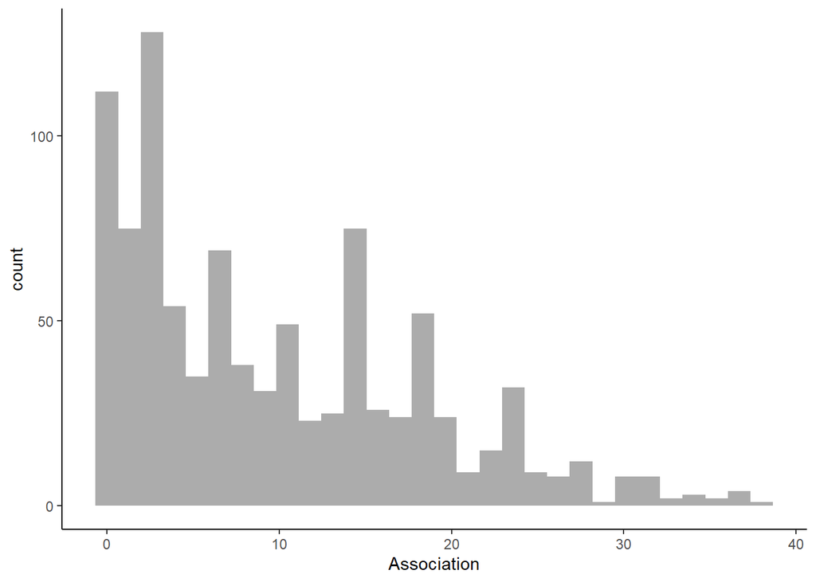

```r
#Association
ggplot(data = data, aes(x= Association)) +
  geom_histogram(alpha = 0.5)+
  theme_classic()
```

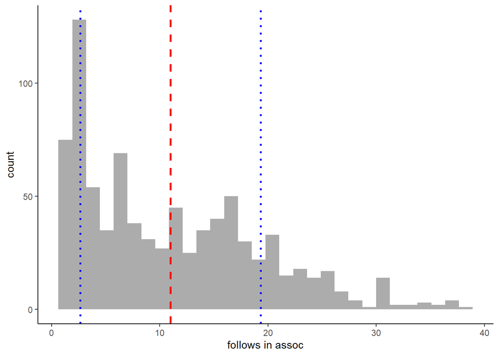

```r
#I have a different number of dyads so lets see if they excluded 0s.... its different both times?? 954 and 842 instead of 936
#lets carry on
data1 <- filter(data, Association > 0)

ggplot(data = data1, aes(x= Association)) +
  geom_histogram(alpha = 0.5)+
  theme_classic()+
  geom_vline(xintercept = mean(data1$Association), color = "red", linetype = "dashed", size = 1)+
  geom_vline(xintercept = mean(data1$Association) + sd(data1$Association), color = "blue", linetype = "dotted", size = 1) +
    geom_vline(xintercept = mean(data1$Association) - sd(data1$Association), color = "blue", linetype = "dotted", size = 1) +
  labs(x = "follows in assoc")
```

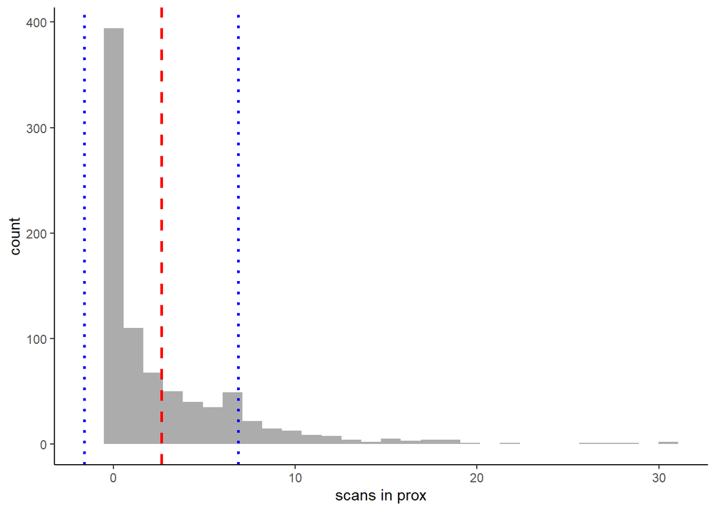

```r
#Proximity
ggplot(data = data1, aes(x= Within_Five)) +
  geom_histogram(alpha = 0.5)+
  theme_classic()+
  geom_vline(xintercept = mean(data1$Within_Five), color = "red", linetype = "dashed", size = 1)+
  geom_vline(xintercept = mean(data1$Within_Five) + sd(data1$Within_Five), color = "blue", linetype = "dotted", size = 1) +
    geom_vline(xintercept = mean(data1$Within_Five) - sd(data1$Within_Five), color = "blue", linetype = "dotted", size = 1)+
  labs(x = "scans in prox")
```

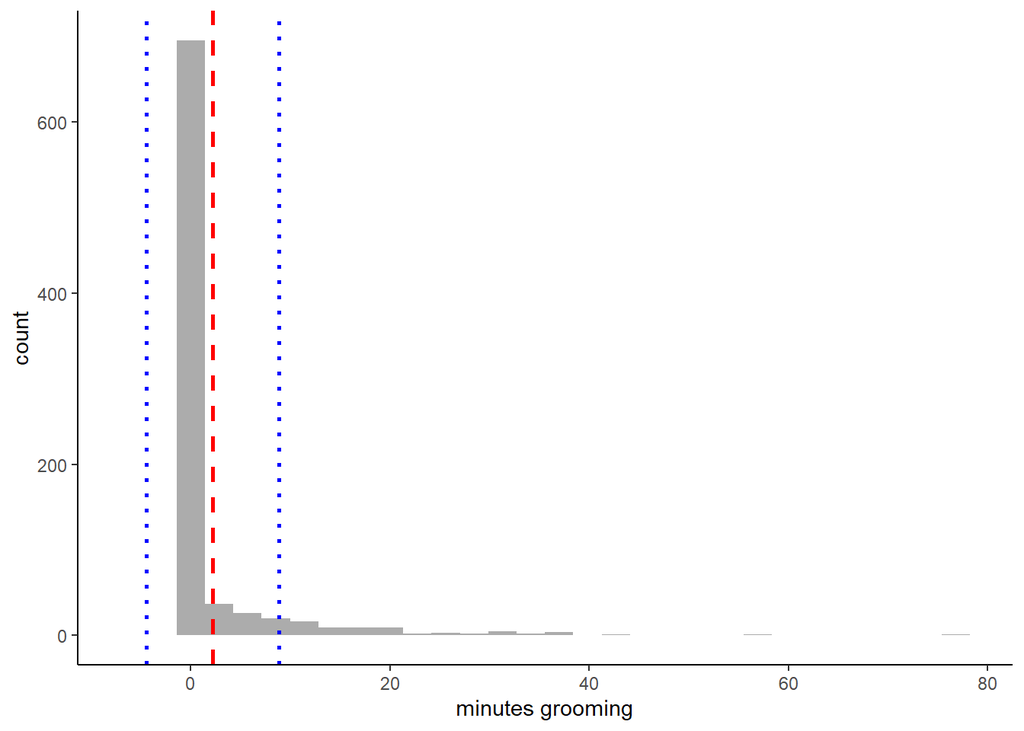

```r
#Grooming
ggplot(data = data1, aes(x= Groom)) +
  geom_histogram(alpha = 0.5)+
  theme_classic()+
  geom_vline(xintercept = mean(data1$Groom), color = "red", linetype = "dashed", size = 1)+
  geom_vline(xintercept = mean(data1$Groom) + sd(data1$Groom), color = "blue", linetype = "dotted", size = 1) +
    geom_vline(xintercept = mean(data1$Groom) - sd(data1$Groom), color = "blue", linetype = "dotted", size = 1)+
  labs(x = "minutes grooming")
```

The figures show the distributions of absolute associations, scans with 5m proximity, and minutes grooming. The red line is the mean and the blue lines are 1SD above and below mean

Now lets take a look at the associations between the variables

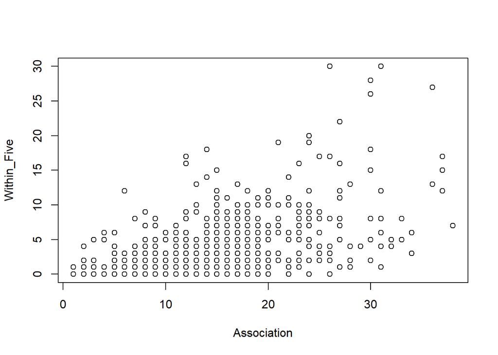

```r
plot(Within_Five~Association, data1)
```

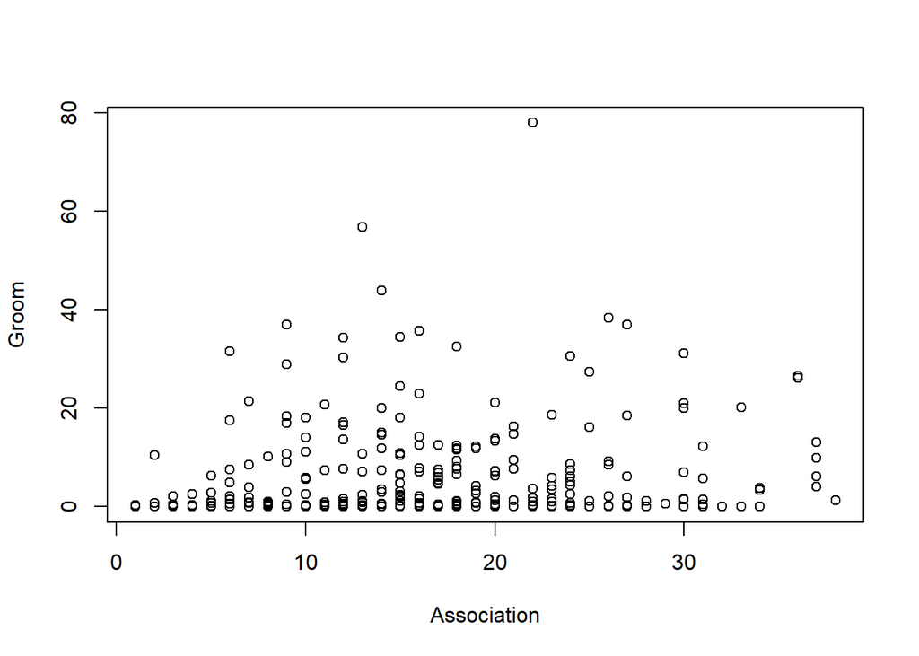

```r
plot(Groom~Association, data1)
```

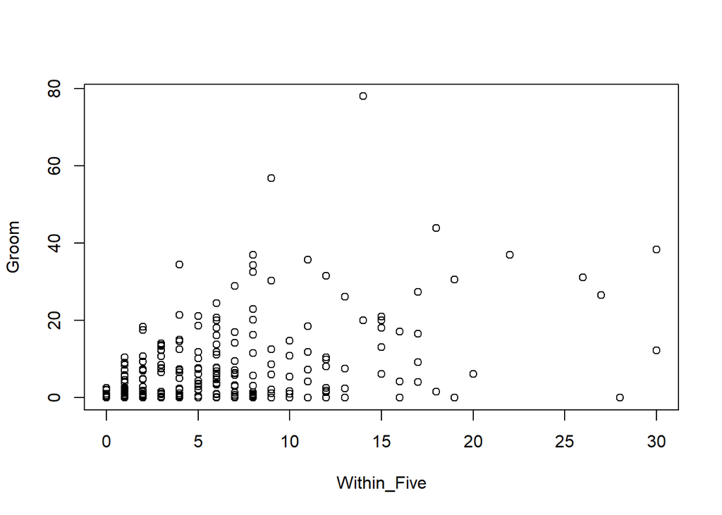

```r
plot(Groom ~ Within_Five, data1)
```

```r
#it looks like prox and association as well as prox and grooming are correlated and perhaps grooming and association are weakly correlated

cor.test(data1$Within_Five, data1$Association)
```

```
##
##  Pearson's product-moment correlation
##
## data:  data1$Within_Five and data1$Association
## t = 23.05, df = 840, p-value < 2.2e-16
## alternative hypothesis: true correlation is not equal to 0
## 95 percent confidence interval:
##  0.5792462 0.6621645
## sample estimates:
##       cor
## 0.6224489
```

```r
cor.test(data1$Groom, data1$Association)
```

```
##
##  Pearson's product-moment correlation
##
## data:  data1$Groom and data1$Association
## t = 8.3331, df = 840, p-value = 3.193e-16
## alternative hypothesis: true correlation is not equal to 0
## 95 percent confidence interval:
##  0.2127345 0.3375853
## sample estimates:
##       cor
## 0.2763253
```

```r
cor.test(data1$Groom, data1$Within_Five)
```

```
##
##  Pearson's product-moment correlation
##
## data:  data1$Groom and data1$Within_Five
## t = 18.899, df = 840, p-value < 2.2e-16
## alternative hypothesis: true correlation is not equal to 0
## 95 percent confidence interval:
##  0.4969793 0.5919207
## sample estimates:
##       cor
## 0.5462018
```

Okay… now I need to create the dyadic indices for each variable in order to determine the bonds of the chimps.”We computed dyadic association by dividing the total number of focal follows during which pairs of males were together by the number of times the focal subject was followed. Dyadic proximity was calculated as the total number of instantaneous samples in which pairs of males were ≤5 m apart, divided by the total number of instantaneous samples for the focal subject. Dyadic grooming was calculated as the total minutes pairs of males spent grooming over the course of the year, divided by the observation hours for the focal subject.”

Pulling from my data1, these will be the equations for the indices So Assoc = Association/Total_Follows Prox = Within_Five/Total_Scans Grooming = Groom/Total_Hours

12-16 adolescents 17-21 adults

```r
Dyad_index_kin <- data1 %>%
  group_by(FocalID, IndividualID, Family) %>%
  summarise(Assoc_index = Association/Total_Follows,
            Prox_index = Within_Five/Total_Scans,
            Groom_index = Groom/Total_Hours,
            Focal_age = Focal_age,
            ID2_age = ID2_age) %>%
  arrange(Family)
# now lets calculate the association strengths for adults/young adults to get bond level
adult_index <- Dyad_index_kin %>%
  filter(Focal_age > 17 & ID2_age > 17)

table_adult <- adult_index %>%
  mutate(meanAssoc = mean(adult_index$Assoc_index),
         meanProx = mean(adult_index$Prox_index),
         meanGroom = mean(adult_index$Groom_index),
         sdAssoc = sd(adult_index$Assoc_index),
         sdProx = sd(adult_index$Prox_index),
         sdGroom = sd(adult_index$Groom_index))


top_10_percent_assoc <- quantile(adult_index$Assoc_index, probs = 0.9, na.rm = TRUE)
top_10_percent_prox <- quantile(adult_index$Prox_index, probs = 0.9, na.rm = TRUE)
top_10_percent_groom <- quantile(adult_index$Groom_index, probs = 0.9, na.rm = TRUE)
```

okay so we have the values for the top 10% of adult relationships which are Association greater than 0.5 Prox greater than 0.0338 Groom greater than 0.316

these values all look correct from the figure in the paper…

```r
#so lets go back to full dataset
#we need to figure out how many bonds individuals formed
# for the t-test we need to find the "mean number bonds displayed by both age classes"

assoc.bond.table <- Dyad_index_kin %>%
  group_by(FocalID)%>%
  filter(Assoc_index >= 0.5)

prox.bond.table <- Dyad_index_kin %>%
  group_by(FocalID)%>%
  filter(Prox_index >= 0.0338)

groom.bond.table <- Dyad_index_kin %>%
  group_by(FocalID)%>%
  filter(Groom_index >= 0.316)

assoc.bond.ind <-
assoc.bond.table %>%
  group_by(FocalID) %>%
  summarize(age.id = mean(Focal_age),
            AssocPartnerBondSum = length(FocalID))

prox.bond.ind <-
prox.bond.table %>%
  group_by(FocalID) %>%
  summarize(age.id = mean(Focal_age),
            ProxPartnerBondSum = length(FocalID))

groom.bond.ind <-
groom.bond.table %>%
  group_by(FocalID) %>%
  summarize(age.id = mean(Focal_age),
            GroomPartnerBondSum = length(FocalID))

#combine sum of bond partner tables
joined_table <- full_join(groom.bond.ind, prox.bond.ind, by = c("FocalID")) %>%
  full_join(., assoc.bond.ind, by = "FocalID")
#get rid of 3 age variable and combine them into 1 column
joined_table <- joined_table %>%
  mutate(age_combined = coalesce(age.id.x, age.id.y, age.id)) %>%
  select(-age.id.x, -age.id.y, -age.id)
```

we have 10 adolescents and 8 young adults which is correct

Now lets calculate the mean number of bonds adolescents form compared to young adults

```r
adol.joined.table <- filter(joined_table, age_combined < 17)
ya.joined.table <- filter(joined_table, age_combined > 17)


adol.joined.table <- adol.joined.table %>%
  mutate(MeanAssocBond = mean(adol.joined.table$AssocPartnerBondSum, na.rm = T),
         sdAssocBond = sd(adol.joined.table$AssocPartnerBondSum, na.rm = T),
         MeanProxBond = mean(adol.joined.table$ProxPartnerBondSum, na.rm = T),
         sdProxBond = sd(adol.joined.table$ProxPartnerBondSum, na.rm = T),
         MeanGroomBond = mean(adol.joined.table$GroomPartnerBondSum, na.rm = T),
         sdGroomBond = sd(adol.joined.table$GroomPartnerBondSum, na.rm = T))

ya.joined.table <- ya.joined.table %>%
  mutate(MeanAssocBond = mean(ya.joined.table$AssocPartnerBondSum, na.rm = T),
         sdAssocBond = sd(ya.joined.table$AssocPartnerBondSum, na.rm = T),
         MeanProxBond = mean(ya.joined.table$ProxPartnerBondSum, na.rm = T),
         sdProxBond = sd(ya.joined.table$ProxPartnerBondSum, na.rm = T),
         MeanGroomBond = mean(ya.joined.table$GroomPartnerBondSum, na.rm = T),
         sdGroomBond = sd(ya.joined.table$GroomPartnerBondSum, na.rm = T))
```

I got different number of mean bonds for each category from the manuscript…

lets do the welchs test to see if they are still consistent

```r
assoc_t_stat <- t.test(x = adol.joined.table$AssocPartnerBondSum, y = ya.joined.table$AssocPartnerBondSum, mu = 0, alternative = "two.sided", var.equal = FALSE)
# var.equal = FALSE is the DEFAULT for `t.test()`
assoc_t_stat
```

```
##
##  Welch Two Sample t-test
##
## data:  adol.joined.table$AssocPartnerBondSum and ya.joined.table$AssocPartnerBondSum
## t = 0.54421, df = 11.55, p-value = 0.5966
## alternative hypothesis: true difference in means is not equal to 0
## 95 percent confidence interval:
##  -2.493522  4.144316
## sample estimates:
## mean of x mean of y
##  6.111111  5.285714
```

```r
prox_t_stat <- t.test(x = adol.joined.table$ProxPartnerBondSum, y = ya.joined.table$ProxPartnerBondSum, mu = 0, alternative = "two.sided", var.equal = FALSE)
# var.equal = FALSE is the DEFAULT for `t.test()`
prox_t_stat
```

```
##
##  Welch Two Sample t-test
##
## data:  adol.joined.table$ProxPartnerBondSum and ya.joined.table$ProxPartnerBondSum
## t = 0.14574, df = 11.136, p-value = 0.8867
## alternative hypothesis: true difference in means is not equal to 0
## 95 percent confidence interval:
##  -2.011438  2.297153
## sample estimates:
## mean of x mean of y
##  3.142857  3.000000
```

```r
groom_t_stat <- t.test(x = adol.joined.table$GroomPartnerBondSum, y = ya.joined.table$GroomPartnerBondSum, mu = 0, alternative = "two.sided", var.equal = FALSE)
# var.equal = FALSE is the DEFAULT for `t.test()`
groom_t_stat
```

```
##
##  Welch Two Sample t-test
##
## data:  adol.joined.table$GroomPartnerBondSum and ya.joined.table$GroomPartnerBondSum
## t = -0.69469, df = 8.1436, p-value = 0.5066
## alternative hypothesis: true difference in means is not equal to 0
## 95 percent confidence interval:
##  -4.411921  2.364302
## sample estimates:
## mean of x mean of y
##  3.142857  4.166667
```

So there are similar findings to the paper with no difference between categories in number of bonds formed per different age categories although I found a different mean…

now lets find the number of ‘triple-bonds’ so we can generate a distribution

```r
#for this we need to join the '.bond.table' files from above


##lets get rid of prox and groom from the assoc table... do the same for other 2 tables and add a 'dyad' column so we can combine tables with only dyads that had triple bonds
assoc.bond.table <- assoc.bond.table %>%
  select(-c(Prox_index, Groom_index)) %>%
  mutate(dyad = paste(FocalID, IndividualID, sep = "_"))

prox.bond.table <- prox.bond.table %>%
  select(-c(Assoc_index, Groom_index)) %>%
  mutate(dyad = paste(FocalID, IndividualID, sep = "_"))

groom.bond.table <- groom.bond.table %>%
  select(-c(Prox_index, Assoc_index)) %>%
  mutate(dyad = paste(FocalID, IndividualID, sep = "_"))


triple_table <- full_join(groom.bond.table, prox.bond.table, by = c("dyad")) %>%
  full_join(., assoc.bond.table, by = "dyad")


### any rows with NA means that they did not have a triple bond so delete those rows
triple_table1 <- triple_table %>%
  drop_na() %>%
  select(-contains(".y"), -contains(".x")) %>%
   select(dyad, FocalID, IndividualID, Family, Groom_index,Prox_index, Assoc_index, Focal_age, ID2_age)
```

From this, it looks like there are 11 triple bonds… 8 of which are from adolescents, 3 are young adults

–I found 11 triple bonds whereas the manuscript found 10–

“Here we calculated the number of times adolescent males exhibited bonds based on all three behaviors divided by the total number of triple bonds formed by adolescent and young adult subjects. We used the resulting percentage as a test statistic”

```r
test_stat <- 8/11
```

“To generate a null distribution of the percentage of strong bonds formed by adolescents, we drew pairs of males at random without replacement from the pool of 936 total dyads, holding the observed number of triple bonds constant. We then calculated the number of times adolescents appeared in the samples of triple bonds relative to the total number of triply‐bonded pairs and used this as one datum in the null distribution. We repeated this process 10,000 times to generate a 95% confidence interval. We compared the observed test statistic to the null distribution to evaluate whether adolescents exhibited strong bonds as frequently as did young adults.”

```r
str(triple_table1)
```

```
## tibble [11 × 9] (S3: tbl_df/tbl/data.frame)
##  $ dyad        : chr [1:11] "Wilson_Bartok" "Booker_Evans" "Mitchell_Mulligan" "Peterson_Carter" ...
##  $ FocalID     : chr [1:11] "Wilson" "Booker" "Mitchell" "Peterson" ...
##  $ IndividualID: chr [1:11] "Bartok" "Evans" "Mulligan" "Carter" ...
##  $ Family      : chr [1:11] "Dad" "MatBro" "MatBro" "MatBro" ...
##  $ Groom_index : num [1:11] 0.652 0.871 0.341 0.759 0.883 ...
##  $ Prox_index  : num [1:11] 0.0592 0.0984 0.119 0.09 0.0777 ...
##  $ Assoc_index : num [1:11] 0.5 0.565 0.816 0.698 0.6 ...
##  $ Focal_age   : num [1:11] 14.8 12.4 15.7 19.7 13.5 ...
##  $ ID2_age     : num [1:11] 41.69 18.68 25.68 24.68 8.59 ...
```

```r
#lets add a new column to the data for triple bonds

data$triple <- 0
data$triple[data$Dyad %in% triple_table1$dyad & data$triple == 0] <- 1


# Initialize an empty vector to store the percentages
null_distribution <- numeric(10000)

# Define a function to generate random samples and calculate percentages
generate_null_distribution <- function(data, triple_bonds, n_samples = 10000) {
  for (i in 1:n_samples) {
    sampled_pairs <- sample(data$Dyad, size = triple_bonds, replace = FALSE)
     adolescents_count <- sum(data$Focal_age[data$Dyad %in% sampled_pairs] < 17)
    percentage <- adolescents_count / triple_bonds
    null_distribution[i] <- percentage
  }
  return(null_distribution)
}

null_distribution <- generate_null_distribution(data, triple_bonds = 11)

head(null_distribution)
```

```
## [1] 0.5454545 0.5454545 0.6363636 0.4545455 0.7272727 0.5454545
```

```r
confidence_interval <- quantile(null_distribution, c(0.025, 0.975))

confidence_interval
```

```
##      2.5%     97.5%
## 0.2727273 0.8181818
```

Lets run the models for association, proxmity, and grooming

```r
library(lme4)
str(data$Family)
```

```
##  chr [1:954] "Unrelated" "Unrelated" "Unrelated" "Unrelated" "Unrelated" ...
```

```r
# Convert 'Family' to a factor
data$Family <- factor(data$Family)

# Check the levels of 'Family' before releveling
levels(data$Family)
```

```
## [1] "Dad"       "MatBro"    "Pat_Bro"   "Unrelated"
```

```r
# Change the reference level to 'Unrelated'
data$Family <- relevel(data$Family, ref = "Unrelated")

# Check the levels of 'Family' after releveling
levels(data$Family)
```

```
## [1] "Unrelated" "Dad"       "MatBro"    "Pat_Bro"
```

```r
data$Family <- relevel(data$Family, ref = "Unrelated")

assoc.model.full <- glmer.nb(Association ~ Focal_age + ID2_age + abs(Age_Diff) + Family +
                    log(Total_Follows) + (1|FocalID) + (1|IndividualID),
                   data = data)
summary(assoc.model.full)
```

```
## Generalized linear mixed model fit by maximum likelihood (Laplace
##   Approximation) [glmerMod]
##  Family: Negative Binomial(1.3324)  ( log )
## Formula: Association ~ Focal_age + ID2_age + abs(Age_Diff) + Family +
##     log(Total_Follows) + (1 | FocalID) + (1 | IndividualID)
##    Data: data
##
##      AIC      BIC   logLik deviance df.resid
##   6228.5   6282.0  -3103.3   6206.5      943
##
## Scaled residuals:
##     Min      1Q  Median      3Q     Max
## -1.0868 -0.7391 -0.1594  0.4199  5.9487
##
## Random effects:
##  Groups       Name        Variance Std.Dev.
##  IndividualID (Intercept) 0.19111  0.43716
##  FocalID      (Intercept) 0.00128  0.03577
## Number of obs: 954, groups:  IndividualID, 54; FocalID, 18
##
## Fixed effects:
##                     Estimate Std. Error z value Pr(>|z|)
## (Intercept)        -1.976157   2.068617  -0.955 0.339424
## Focal_age           0.001717   0.013691   0.125 0.900221
## ID2_age             0.021923   0.009026   2.429 0.015148 *
## abs(Age_Diff)      -0.004872   0.010798  -0.451 0.651873
## FamilyDad           0.179260   0.294652   0.608 0.542935
## FamilyMatBro        0.884613   0.240722   3.675 0.000238 ***
## FamilyPat_Bro      -0.021019   0.170244  -0.123 0.901737
## log(Total_Follows)  0.959370   0.524471   1.829 0.067367 .
## ---
## Signif. codes:  0 '***' 0.001 '**' 0.01 '*' 0.05 '.' 0.1 ' ' 1
##
## Correlation of Fixed Effects:
##             (Intr) Focl_g ID2_ag a(A_D) FmlyDd FmlyMB FmlP_B
## Focal_age   -0.354
## ID2_age     -0.042 -0.110
## abs(Ag_Dff)  0.018  0.151 -0.759
## FamilyDad    0.033 -0.005 -0.038 -0.021
## FamilyMatBr -0.050  0.059 -0.003  0.013  0.015
## FamilyPt_Br  0.010  0.025  0.043 -0.030  0.011  0.026
## lg(Ttl_Fll) -0.992  0.258 -0.002 -0.013 -0.031  0.042 -0.019
```

```r
#now lets do the same but without 0 values for association...aka use data1

# Convert 'Family' to a factor
data1$Family <- factor(data1$Family)

# Check the levels of 'Family' before releveling
levels(data1$Family)
```

```
## [1] "Dad"       "MatBro"    "Pat_Bro"   "Unrelated"
```

```r
# Change the reference level to 'Unrelated'
data1$Family <- relevel(data1$Family, ref = "Unrelated")

# Check the levels of 'Family' after releveling
levels(data1$Family)
```

```
## [1] "Unrelated" "Dad"       "MatBro"    "Pat_Bro"
```

```r
data1$Family <- relevel(data1$Family, ref = "Unrelated")

assoc.model <- glmer.nb(Association ~ Focal_age + ID2_age + abs(Age_Diff) + Family +
                    log(Total_Follows) + (1|FocalID) + (1|IndividualID),
                   data = data1)
```

```
## boundary (singular) fit: see help('isSingular')
```

```r
summary(assoc.model)
```

```
## Generalized linear mixed model fit by maximum likelihood (Laplace
##   Approximation) [glmerMod]
##  Family: Negative Binomial(2.2475)  ( log )
## Formula: Association ~ Focal_age + ID2_age + abs(Age_Diff) + Family +
##     log(Total_Follows) + (1 | FocalID) + (1 | IndividualID)
##    Data: data1
##
##      AIC      BIC   logLik deviance df.resid
##   5616.0   5668.1  -2797.0   5594.0      831
##
## Scaled residuals:
##     Min      1Q  Median      3Q     Max
## -1.2934 -0.7902 -0.0938  0.5058  4.8773
##
## Random effects:
##  Groups       Name        Variance  Std.Dev.
##  IndividualID (Intercept) 1.021e-01 3.196e-01
##  FocalID      (Intercept) 6.288e-12 2.508e-06
## Number of obs: 842, groups:  IndividualID, 54; FocalID, 18
##
## Fixed effects:
##                     Estimate Std. Error z value Pr(>|z|)
## (Intercept)        -0.305026   1.704711  -0.179  0.85799
## Focal_age          -0.009552   0.011047  -0.865  0.38723
## ID2_age             0.018821   0.007141   2.636  0.00839 **
## abs(Age_Diff)      -0.009725   0.008806  -1.104  0.26946
## FamilyDad           0.118536   0.233376   0.508  0.61151
## FamilyMatBro        0.747368   0.188976   3.955 7.66e-05 ***
## FamilyPat_Bro      -0.096669   0.139493  -0.693  0.48831
## log(Total_Follows)  0.641270   0.432616   1.482  0.13826
## ---
## Signif. codes:  0 '***' 0.001 '**' 0.01 '*' 0.05 '.' 0.1 ' ' 1
##
## Correlation of Fixed Effects:
##             (Intr) Focl_g ID2_ag a(A_D) FmlyDd FmlyMB FmlP_B
## Focal_age   -0.350
## ID2_age     -0.045 -0.129
## abs(Ag_Dff)  0.026  0.173 -0.784
## FamilyDad    0.037 -0.008 -0.040 -0.021
## FamilyMatBr -0.047  0.058 -0.002  0.012  0.019
## FamilyPt_Br  0.003  0.034  0.046 -0.031  0.013  0.028
## lg(Ttl_Fll) -0.993  0.256  0.007 -0.025 -0.034  0.039 -0.013
## optimizer (Nelder_Mead) convergence code: 0 (OK)
## boundary (singular) fit: see help('isSingular')
```

```r
##For grooming and prox. lets run models with data1 since pairs needed to associate at least once
#proximity
prox.model <- glmer.nb(Within_Five ~ Focal_age + ID2_age + abs(Age_Diff) + Family + log(Association) + (1|FocalID) + (1|IndividualID), data1)
summary(prox.model)
```

```
## Generalized linear mixed model fit by maximum likelihood (Laplace
##   Approximation) [glmerMod]
##  Family: Negative Binomial(1.7669)  ( log )
## Formula: Within_Five ~ Focal_age + ID2_age + abs(Age_Diff) + Family +
##     log(Association) + (1 | FocalID) + (1 | IndividualID)
##    Data: data1
##
##      AIC      BIC   logLik deviance df.resid
##   2807.6   2859.7  -1392.8   2785.6      831
##
## Scaled residuals:
##     Min      1Q  Median      3Q     Max
## -1.1837 -0.6185 -0.3043  0.2005 10.3217
##
## Random effects:
##  Groups       Name        Variance Std.Dev.
##  IndividualID (Intercept) 0.05677  0.2383
##  FocalID      (Intercept) 0.06416  0.2533
## Number of obs: 842, groups:  IndividualID, 54; FocalID, 18
##
## Fixed effects:
##                   Estimate Std. Error z value Pr(>|z|)
## (Intercept)      -3.620497   0.529449  -6.838 8.02e-12 ***
## Focal_age        -0.003211   0.029829  -0.108  0.91427
## ID2_age           0.050936   0.009561   5.328 9.94e-08 ***
## abs(Age_Diff)    -0.038093   0.011733  -3.247  0.00117 **
## FamilyDad         0.579740   0.296464   1.956  0.05052 .
## FamilyMatBro      0.935680   0.235001   3.982 6.85e-05 ***
## FamilyPat_Bro     0.204212   0.216229   0.944  0.34495
## log(Association)  1.454059   0.067376  21.581  < 2e-16 ***
## ---
## Signif. codes:  0 '***' 0.001 '**' 0.01 '*' 0.05 '.' 0.1 ' ' 1
##
## Correlation of Fixed Effects:
##             (Intr) Focl_g ID2_ag a(A_D) FmlyDd FmlyMB FmlP_B
## Focal_age   -0.904
## ID2_age     -0.041 -0.174
## abs(Ag_Dff) -0.060  0.197 -0.878
## FamilyDad   -0.003  0.002 -0.028 -0.046
## FamilyMatBr -0.008  0.017  0.086 -0.064  0.008
## FamilyPt_Br -0.068  0.025  0.082 -0.040  0.014  0.050
## log(Assctn) -0.347  0.042 -0.089  0.080  0.042 -0.139  0.004
```

```r
#grooming
data2 <- data1
data2$Groom <- as.integer(data2$Groom)

# Fit negative binomial model with integer Groom variable
groom.model <- glmer.nb(Groom ~ Focal_age + ID2_age + abs(Age_Diff) + Family + log(Association) + (1|FocalID) + (1|IndividualID), data = data2)
summary(groom.model)
```

```
## Generalized linear mixed model fit by maximum likelihood (Laplace
##   Approximation) [glmerMod]
##  Family: Negative Binomial(0.1451)  ( log )
## Formula:
## Groom ~ Focal_age + ID2_age + abs(Age_Diff) + Family + log(Association) +
##     (1 | FocalID) + (1 | IndividualID)
##    Data: data2
##
##      AIC      BIC   logLik deviance df.resid
##   1766.3   1818.4   -872.1   1744.3      831
##
## Scaled residuals:
##     Min      1Q  Median      3Q     Max
## -0.3797 -0.3462 -0.2388 -0.0854 13.1831
##
## Random effects:
##  Groups       Name        Variance Std.Dev.
##  IndividualID (Intercept) 0.5642   0.7512
##  FocalID      (Intercept) 0.6430   0.8019
## Number of obs: 842, groups:  IndividualID, 54; FocalID, 18
##
## Fixed effects:
##                  Estimate Std. Error z value Pr(>|z|)
## (Intercept)      -9.67753    1.74848  -5.535 3.12e-08 ***
## Focal_age         0.14025    0.09387   1.494   0.1352
## ID2_age           0.12225    0.03006   4.067 4.77e-05 ***
## abs(Age_Diff)    -0.07740    0.03649  -2.121   0.0339 *
## FamilyDad         2.26687    0.95038   2.385   0.0171 *
## FamilyMatBro      0.08509    0.83851   0.101   0.9192
## FamilyPat_Bro    -1.02374    0.76756  -1.334   0.1823
## log(Association)  2.03104    0.21502   9.446  < 2e-16 ***
## ---
## Signif. codes:  0 '***' 0.001 '**' 0.01 '*' 0.05 '.' 0.1 ' ' 1
##
## Correlation of Fixed Effects:
##             (Intr) Focl_g ID2_ag a(A_D) FmlyDd FmlyMB FmlP_B
## Focal_age   -0.888
## ID2_age     -0.158 -0.096
## abs(Ag_Dff)  0.008  0.123 -0.852
## FamilyDad   -0.059  0.011 -0.008 -0.052
## FamilyMatBr -0.040  0.084  0.059 -0.088 -0.021
## FamilyPt_Br  0.010 -0.002  0.005  0.008 -0.030  0.008
## log(Assctn) -0.366  0.040  0.009  0.049  0.181 -0.166 -0.058
```

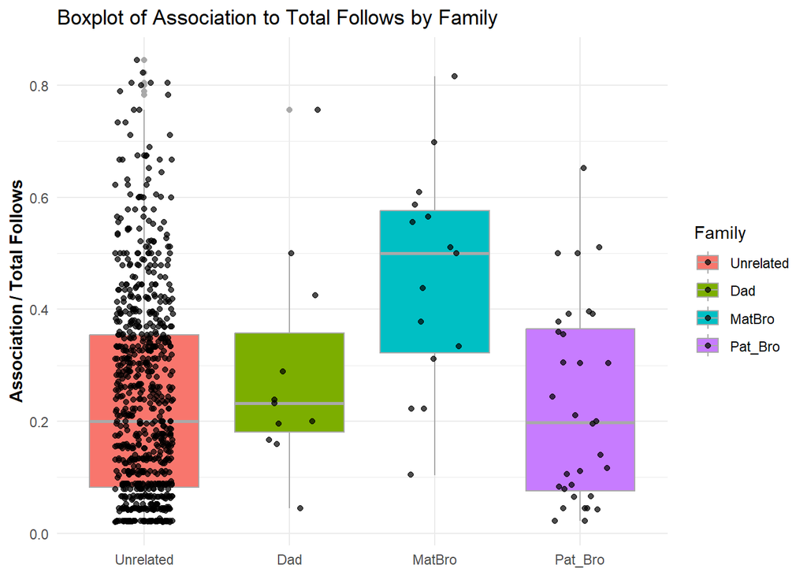

```r
library(ggplot2)

# Create a new variable for Association/Total_Follows
data1$Assoc_Ratio <- data1$Association / data1$Total_Follows

# Create the boxplot using ggplot
ggplot(data1, aes(x = Family, y = Assoc_Ratio, fill = Family)) +
  geom_boxplot(color = "darkgray") +
  geom_jitter(width = 0.2, alpha = 0.7, color = "black") +
  labs(
    x = NULL,
    y = expression(bold("Association" ~ "/" ~ "Total Follows")),
    title = "Boxplot of Association to Total Follows by Family"
  ) +
  theme_minimal()
```

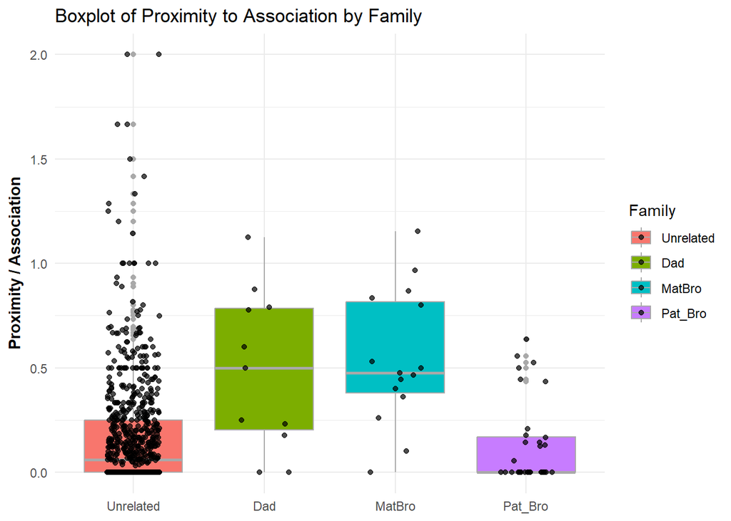

```r
# Create a new variable for the ratio
data1$ProxRatio <- data1$Within_Five / data1$Association

# Create the boxplot using ggplot
ggplot(data1, aes(x = Family, y = ProxRatio, fill = Family)) +
  geom_boxplot(color = "darkgray") +
  geom_jitter(width = 0.2, alpha = 0.7, color = "black") +
  labs(
    x = NULL,
    y = expression(bold("Proximity" ~ "/" ~ "Association")),
    title = "Boxplot of Proximity to Association by Family"
  ) +
  theme_minimal()
```

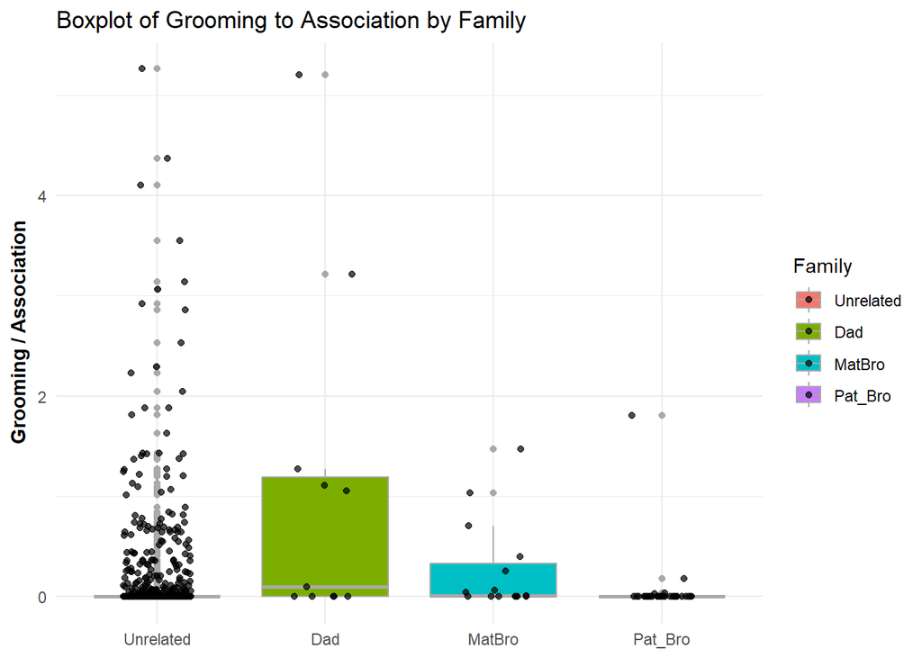

```r
# Create a new variable for the groom ratio
data1$GroomRatio <- data1$Groom / data1$Association

# Create the boxplot using ggplot
ggplot(data1, aes(x = Family, y = GroomRatio, fill = Family)) +
  geom_boxplot(color = "darkgray") +
  geom_jitter(width = 0.2, alpha = 0.7, color = "black") +
  labs(
    x = NULL,
    y = expression(bold("Grooming" ~ "/" ~ "Association")),
    title = "Boxplot of Grooming to Association by Family"
  ) +
  theme_minimal()
```

Discussion:

This assignment was enlightening to the challenges of recreating and having reproducible research based on description alone. Obviously, there is issue in the sense that I could not even get the same sample size based on the data set provided. Aaron and the other co-authors knew why they reduced the sample, but I can only assume (death of a male within the sample). Even if I am correct, I do not know which male and I do not know if they remove him from the very beginning or include him for a certain amount of time. I also found a discrepency in the demographic data as Mulligan and Mitchell are maternal brothers. Perhaps this was not known during the time of writing the manuscript and does not likely alter the results a great deal. However, the more accurate the data, the better! Although my sample size was slightly different, I was largely quite accurate in my re-analysis of the data provided.

All of the major findings of the paper are further supported by my analysis and the major effects remain the same. Perhaps unsurprisingly, the hardest part of the assignment was the data organization and trying to replicate the descriptive statistics and preliminary analyses. I especially had trouble with recreating their analysis of triple-bonds using only their description of the permutation process. I was able to calculate a similar test-statistic but may have failed to calculate a correct null distribution for testing.

So adolescent chimpanzees preferably associate and sit with their maternal brothers and groom their biological fathers. This is an interesting result that should be further explored with the inclusion of females within the analyses. This could help understand mating strategies, strength of male-female bonds in comparison to male-male, and what females are important partners during the transition to adulthood. Stay tuned for a manuscript from myself and Aaron soon.